# Assignment1

2022-10-01

# Data Wrangling

The data from a fictional ecological study. The research was conducted over a ten year period (2011-2020) across five widely dispersed field sites. Individual animals from two sister species (A fictus and A mendacium) were observed, and data was recorded on their size (weight and height) and range.

1. The roaming range of the animal (in square km)
2. The weight of the animal (in kg)
3. The height of the animal (in cm)
4. The species of the animal (A fictus or A mendacium)
5. The year that the measurements were taken (2011-2020)

## Libraries and Packages

Load in the corresponding libraries, tidyverse as well as readxl.

## Import CSV files

The data is in an Excel file (“BIOL3207_Assignment1_DataFile.xlsx”) in which each of the five field sites is a separate sheet. Each row represents measurements from a single animal.

```
## # A tibble: 200 × 5
##    `Range (square km)` `Weight (kg)` `Height (cm)` Species      Year
##                  <dbl>         <dbl>         <dbl> <chr>       <dbl>
##  1                61.6         19.1           64.3 A fictus     2011
##  2                64.2         13.6           28.2 A fictus     2011
##  3                52.7         11.4           63.1 A mendacium  2011
##  4                67.5         12.9           54.6 A fictus     2011
##  5                55.8         10.9           71.8 A fictus     2011
##  6                76.1          6.78          66.9 A mendacium  2011
##  7                62.8         17.1           64.3 A fictus     2011
##  8                62.9         12.3           48.1 A fictus     2011
##  9                51.8          9.09          90.6 A fictus     2011
## 10                56.1         17.2           43.4 A fictus     2011
## # … with 190 more rows
```

## Motified the CSV files

Get the names of the sheets.

```r
sample_ids <- excel_sheets(meta_data_file1)
sample_ids #"Field Site 1" "Field Site 2" "Field Site 3" "Field Site 4" "Field Site 5"
```

```
## [1] "Field Site 1" "Field Site 2" "Field Site 3" "Field Site 4" "Field Site 5"
```

Assign the spreadsheet into different variables and use the function `do.call()` to make the variable assignment. Import the remaining sheets into variables using the same naming convention.

```r
string <- c("Field Site 1","Field Site 2","Field Site 3","Field Site 4","Field Site 5")
string <- trimws(gsub("\\s+", "_", string))# the elements in string:"Field_Site_1" "Field_Site_2" "Field_Site_3" "Field_Site_4" "Field_Site_5"

# Import the remaining sheets into variables
do.call("<-",list(paste(string[1],"_assign",sep = ""),read_xlsx(meta_data_file1,sheet=sample_ids[1],skip=7)))
# Loop
for (i in c(2,3,4,5)) {

  do.call("<-",list(paste(string[i],"_assign",sep = ""),read_xlsx(meta_data_file1,sheet=sample_ids[i])))
}
```

Create a new string as desired, which could be used as variable names

```r
string2 <- str_c(string,"_assign")# create a list of sheet names
string2# variable names: "Field_Site_1_assign" "Field_Site_2_assign" "Field_Site_3_assign" "Field_Site_4_assign" "Field_Site_5_assign"
```

```
## [1] "Field_Site_1_assign" "Field_Site_2_assign" "Field_Site_3_assign"
## [4] "Field_Site_4_assign" "Field_Site_5_assign"
```

Add a column of Sites, make sure one tibble includes all of the data, which Sites as a variable in a new column.

```r
# Create a New string of 1,2,3,4,5
String3 <- c(1,2,3,4,5)
#add column to all data
Field_Site_1_assign <- add_column(Field_Site_1_assign,Sites=String3[1])
Field_Site_2_assign <- add_column(Field_Site_2_assign,Sites=String3[2])
Field_Site_3_assign <- add_column(Field_Site_3_assign,Sites=String3[3])
Field_Site_4_assign <- add_column(Field_Site_4_assign,Sites=String3[4])
Field_Site_5_assign <- add_column(Field_Site_5_assign,Sites=String3[5])
```

## Create tidy tibble containing all of the data and rename all of columns

```r
assign <- bind_rows(Field_Site_1_assign,Field_Site_2_assign,Field_Site_3_assign,Field_Site_4_assign,Field_Site_5_assign)# combine all of data
names(assign) <- c('Range','Weight','Height','Species','Year','Sites') # rename the column names
str(assign)
```

```
## tibble [1,000 × 6] (S3: tbl_df/tbl/data.frame)
##  $ Range  : num [1:1000] 61.6 64.2 52.7 67.5 55.8 ...
##  $ Weight : num [1:1000] 19.1 13.6 11.4 12.9 10.9 ...
##  $ Height : num [1:1000] 64.3 28.2 63.1 54.6 71.8 ...
##  $ Species: chr [1:1000] "A fictus" "A fictus" "A mendacium" "A fictus" ...
##  $ Year   : num [1:1000] 2011 2011 2011 2011 2011 ...
##  $ Sites  : num [1:1000] 1 1 1 1 1 1 1 1 1 1 ...
```

### Identify and address problematic entries.

```r
assign <- assign %>% na.omit() # get rid of all NA entries/ Omit all unnecessary entries
assign <- assign %>% group_by(Sites,Year,Species)# group by Species,Sample_id and Year

# Find out the mistake of spelling
assign$Species %>% unique() # "A fictus"    "A mendacium" "A Mendacium"
```

```
## [1] "A fictus"    "A mendacium" "A Mendacium"
```

```r
assign$Year %>% unique() # 2011 2012 2013 2014 2015 2016 2017 2018 2019 2020 2217
```

```
##  [1] 2011 2012 2013 2014 2015 2016 2017 2018 2019 2020 2217
```

```r
# Clear the wrong data
assign <- assign %>% filter(Weight>0) %>% mutate(Species = stringr::str_replace(Species,"A Mendacium","A mendacium"),Year = stringr::str_replace(Year,"2217","2017"))

# check the motified spelling
assign$Year %>% unique() #"2011" "2012" "2013" "2014" "2015" "2016" "2017" "2018" "2019" "2020"
```

```
##  [1] "2011" "2012" "2013" "2014" "2015" "2016" "2017" "2018" "2019" "2020"
```

```r
assign$Species %>% unique() #"A fictus"    "A mendacium"
```

```
## [1] "A fictus"    "A mendacium"
```

### Convert some data into factors

Make some variables transformed into factors, it could specify the process of analysis.

```r
# Convert the Years into factors
assign$Year <- factor(assign$Year, levels = c("2011", "2012", "2013", "2014", "2015", "2016", "2017" ,"2018", "2019", "2020"))

# Convert Sample_id into factors
assign$Sites <- factor(assign$Sites, levels = c("1", "2", "3", "4", "5"))

# Convert the Species into factors
assign$Species <- factor(assign$Species, levels = c('A fictus','A mendacium'))
```

```r
library(writexl)
writexl::write_xlsx(assign, path  = "data/u7457462_BIOL3207_Assignment1_DataFile.xlsx") # export the excel file
```

# Data analysis

## Create a plot to visualise many relationships at once. Library ggpairs in the package GGally.

Here are 6 variables, from this picture, I could get some information about the correlation between two variables. I could not determine whether it is correct or not, so I try to figure out what patterns and relationships in the data. Actually, I do a lot of guessing and work in analyzing the linear model one by one. Most of them don’t show the correlation, so I just plot those specific relationships I find.

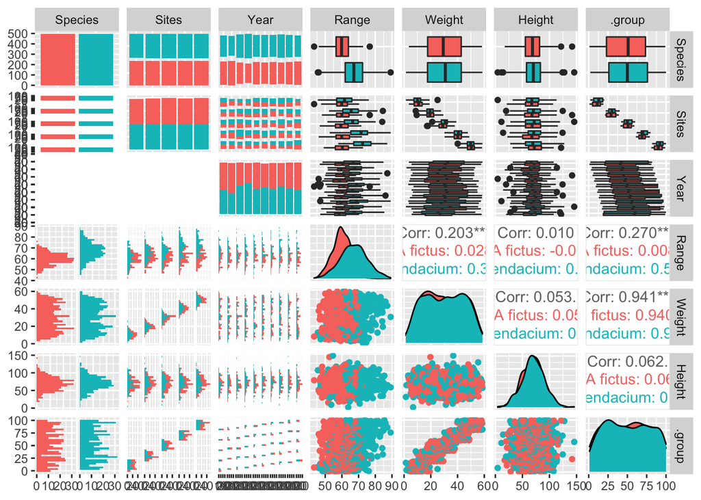

fig1

```r
library(GGally)
assign %>% select(Species,Sites,Year,Range,Weight,Height) %>% ggpairs(aes(col= Species))
```

From the ggpairs plot, it is easy to see that the correlation higher than 0.1 is betwwen Range and weight, range and .group, weight and .group. So I am gonna to analyse what patterns do they have.

## Weight and Sites

### Limear model analysis

Use the `lm()` to simulate the linear model ,`emmeans()` to get the estimated means for each class. and use `summary()` to get the key components.

```r
# The correlation of Weight and Sites
library(emmeans)
lm_WS_assign <- lm(Weight~Sites,assign)
emmeans(lm_WS_assign,~Sites)
```

```
##  Sites emmean    SE  df lower.CL upper.CL
##  1       10.5 0.281 989     9.97     11.1
##  2       19.4 0.279 989    18.84     19.9
##  3       29.5 0.278 989    28.93     30.0
##  4       40.3 0.279 989    39.73     40.8
##  5       49.9 0.278 989    49.33     50.4
##
## Confidence level used: 0.95
```

```r
summary(lm_WS_assign)
```

```
##
## Call:
## lm(formula = Weight ~ Sites, data = assign)
##
## Residuals:
##      Min       1Q   Median       3Q      Max
## -12.2839  -2.5730   0.0999   2.5473  14.5353
##
## Coefficients:
##             Estimate Std. Error t value Pr(>|t|)
## (Intercept)  10.5227     0.2807   37.48   <2e-16 ***
## Sites2        8.8603     0.3955   22.40   <2e-16 ***
## Sites3       18.9541     0.3950   47.98   <2e-16 ***
## Sites4       29.7582     0.3955   75.24   <2e-16 ***
## Sites5       39.3573     0.3950   99.63   <2e-16 ***
## ---
## Signif. codes:  0 '***' 0.001 '**' 0.01 '*' 0.05 '.' 0.1 ' ' 1
##
## Residual standard error: 3.93 on 989 degrees of freedom
## Multiple R-squared:  0.928,  Adjusted R-squared:  0.9277
## F-statistic:  3187 on 4 and 989 DF,  p-value: < 2.2e-16
```

Conclusion: The Multiple R-squared equal 0.928, that shows that the model can explain 92.8% of the variance in body weight, which is also the correlation coefficient between actual and predicted values. From the emmean values, the Weight would rise in different Sites in order from Sites1 to Sites5.

### Create ggplots

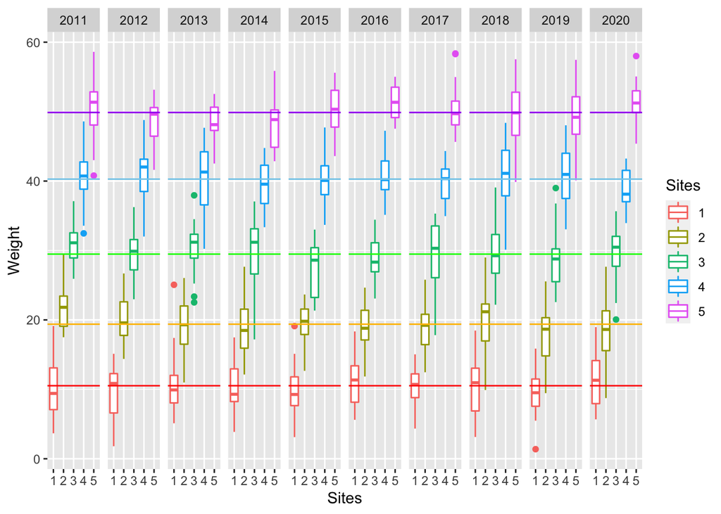

fig2

```r
# Calculate all means of Weight in Differnt Sites
Sites_specific_means <- assign %>% group_by(Sites) %>% summarise(val = mean(Weight)) %>% pull(val)
assign %>%  ggplot(aes(y=Weight,x=Sites,colour=Sites)) +facet_wrap(~Year,nrow = 1)+geom_boxplot() + geom_hline(yintercept=Sites_specific_means[1],colour="red") + geom_hline(yintercept=Sites_specific_means[2],colour="#FFBF00FF")+ geom_hline(yintercept=Sites_specific_means[3],colour="Green")+ geom_hline(yintercept=Sites_specific_means[4],colour="skyBlue")+ geom_hline(yintercept=Sites_specific_means[5],colour="purple")# add a mean line for every mean values to indicate the changes among Sites
```

## Range, Weight and Sites

### Create the exploratory boxplot

Use the ggplot to create the boxplot between Range and Sites, Use `facet_wrap()` to show the difference between Species.

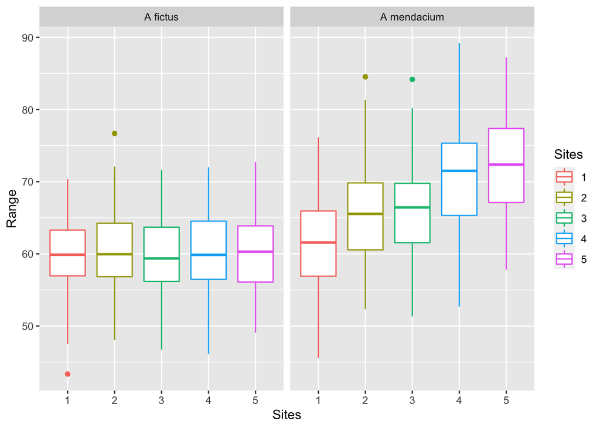

fig3

```r
# The range distribution in different Sites
ggplot(assign,aes(y=Range,x=Sites,col=Sites))+facet_wrap(~Species,nrow = 1)+geom_boxplot()# No difference in A fictus, some differences in A mendacium
```

To figure out whether the Species *A fictus* fit the linear model, I divide the data into two single-Specie datasets, and use `lm()` to calculate the Multiple R-squared values. The result is that Species *A fictus* could not fit the linear model with Sites. After calculating the Multiple R-squared values, I find the value of Species *A mendacium* is 0.257, I dicide to only analyse the pattern of Species *A mendacium* with Weight.

```r
# Separate the whole data into two single Specie datasets
assign_Species1 <- assign %>% filter(Species=='A fictus')
assign_Species2 <- assign %>% filter(Species=='A mendacium')

lm_RS_Species1<- lm(Range~Sites,assign_Species1)# Multiple R-squared:  0.00314
lm_RS_Species2<- lm(Range~Sites,assign_Species2)# Multiple R-squared:  0.257
```

### Data analysis and ggplot

```r
# Only choose the Species A mendacium to analyse
lm_RS_Species2<- lm(Range~Sites+Weight,assign_Species2)
summary(lm_RS_Species2) # conclusion: there are some differences in A mendacium at different Sites
```

```
##
## Call:
## lm(formula = Range ~ Sites + Weight, data = assign_Species2)
##
## Residuals:
##      Min       1Q   Median       3Q      Max
## -18.5353  -4.0796   0.3569   4.2025  19.2599
##
## Coefficients:
##             Estimate Std. Error t value Pr(>|t|)
## (Intercept) 69.91731    0.95450   73.25   <2e-16 ***
## Sites2      11.80327    1.07428   10.99   <2e-16 ***
## Sites3      21.79442    1.66751   13.07   <2e-16 ***
## Sites4      35.26259    2.32343   15.18   <2e-16 ***
## Sites5      45.14147    2.96748   15.21   <2e-16 ***
## Weight      -0.85626    0.07179  -11.93   <2e-16 ***
## ---
## Signif. codes:  0 '***' 0.001 '**' 0.01 '*' 0.05 '.' 0.1 ' ' 1
##
## Residual standard error: 6.054 on 492 degrees of freedom
## Multiple R-squared:  0.4238, Adjusted R-squared:  0.4179
## F-statistic: 72.36 on 5 and 492 DF,  p-value: < 2.2e-16
```

Use `ggplot` to draw the lines examine how Range depends on Weights. Use `facet_wrap` to make an informative plot.

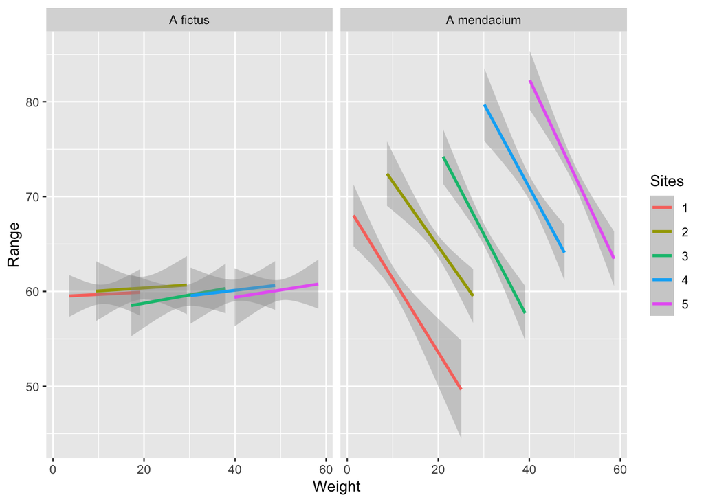

fig4

```r
# the relationship between  Range and Ratio of different Species
assign %>%  ggplot( mapping = aes(x =Weight, y = Range,colour = Sites)) +facet_wrap(~Species)+geom_smooth(method = 'lm')
```

```r
# Negative Correlation plot
```

From the previous plot, it is easy to see that the Species *A mendacium* has a Negative correlation of Weight and Range. I straightforward calculate per correlation of the lines.

```r
# Calulate all correlations between Range and Weight in Different Sites
correlations <- c()
assign_Species2_Sites1 <- assign_Species2 %>% filter(Sites==1)
correlations[1] <- cor(assign_Species2_Sites1$Range,
                    assign_Species2_Sites1$Weight)
assign_Species2_Sites1 <- assign_Species2 %>% filter(Sites==2)
correlations[2] <- cor(assign_Species2_Sites1$Range,
                    assign_Species2_Sites1$Weight)
assign_Species2_Sites1 <- assign_Species2 %>% filter(Sites==3)
correlations[3] <- cor(assign_Species2_Sites1$Range,
                    assign_Species2_Sites1$Weight)
assign_Species2_Sites1 <- assign_Species2 %>% filter(Sites==4)
correlations[4] <- cor(assign_Species2_Sites1$Range,
                    assign_Species2_Sites1$Weight)
assign_Species2_Sites1 <- assign_Species2 %>% filter(Sites==5)
correlations[5] <- cor(assign_Species2_Sites1$Range,
                    assign_Species2_Sites1$Weight)
correlations#-0.4229692 -0.4065526 -0.5307098 -0.4483852 -0.5613249
```

```
## [1] -0.4229692 -0.4065526 -0.5307098 -0.4483852 -0.5613249
```